# **Mass Shooting Report for 2018**

## *Interactive Map*

This map is to illustrate where all the shootings have occurred during the year of 2018. In this map, the blue circle represents the number of people who were injured in a shooting, and the red circle represents the number of people who were killed in a shooting. The darker the circles are, the more shootings there was in that general area. The size of the circle represents the amount of people who were either killed or injured. The bigger the circle, the more people killed or injured during the shooting.

This map is used to help show where majority of the shootings occurred in the United States. Additionally, my map helps show where the shooting with the most cause of death or injury occurs as well. For example, you can see that there is a huge blue circle in Philadelphia. This huge circle represents a shooting that caused 19 injuries towards people. This map helps distinguish which shooting caused the most death and most injuries between states.

[interactive chart not shown]

An interesting thing I noticed from my map is that majority of the shootings occurred in the eastern part of the United states. Splitting the US in half, you can see that a lot of states and cities on the right side of the map are being experiencing many shootouts compared to the left side.

Another interesting thing I noticed from my map is that there are very few to no shootings occurring in the upper most part of the United States. You can see that there were no shootings in Montana, North Dakota, South Dakota, and Wyoming. I’m surprised that there weren’t any shootings recorded, but again that’s really good to hear.

## *State Most Impacted By Shootings*

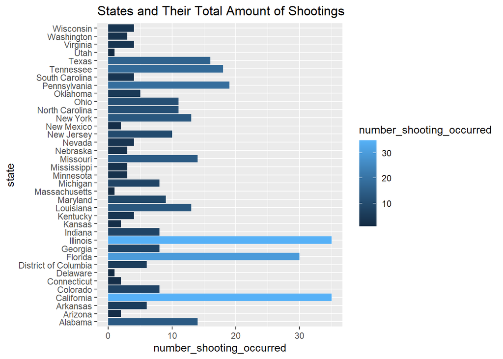

This bar chart helps distinguish the amount of shootings occurring in different states. This is a really good choice of chart to display this information because you can instantly tell which bar has the most and which has the least. Plus, the color helps to see which bar is more because the lighter the bar, the more shootings have occurred in the state. With this chart, you can instantly tell that the two states most affected by the shootings were California and Illinois.

An interesting thing I noticed was that the states less impacted by the shootings were Utah, Massachusetts, and Delaware. Kind of makes sense too because we rarely hear any news in relation to those states. Another interesting thing I noticed about this is that the top three states impacted by shootings are the states that we hear the most of on the news.